# Week of 03/14/2022

Zachary Rowson

3/18/2022

## What was accomplished

Woody expressed concern about the heteroscedasticity of the sum movement by time distributions and the bounded distribution of residuals. In order to combat these issues Woody suggested power transforming the data either logarithmically or 1/2 power. Which transformation to perform needs to be determined.

My approach to this question has been visual assessment of the time series data, evaluating the symmetry of movement by time distributions over all fish analyzed in the DNT60 experiment. Observing an apparent increase in symmetry of the distributions and decrease in the scale of the distribution of sample variances for all time period distributions after transformation may a good enough evaluation.

I conclude, using these evaluation methods, That log transformation appears to be best. However, transforming Light and Dark data with different transformations may be best.

Fitting the transformed data with LMEs and evaluating the residuals of the fit would be a better evaluation.

## Load Data

```r
load("../data/Padilla_DNT60_pmr0_long.rda")
DNT60pmr0_long[, logy := log10(y + 1)]
DNT60pmr0_long[, sqrty := sqrt(y)]
```

## Evaluate transformation-induced symmetry

Evaluate the symmetry of sum movement distributions by time after log10() or sqrt() transformation.

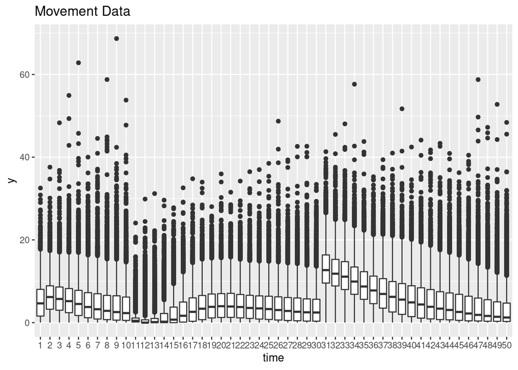

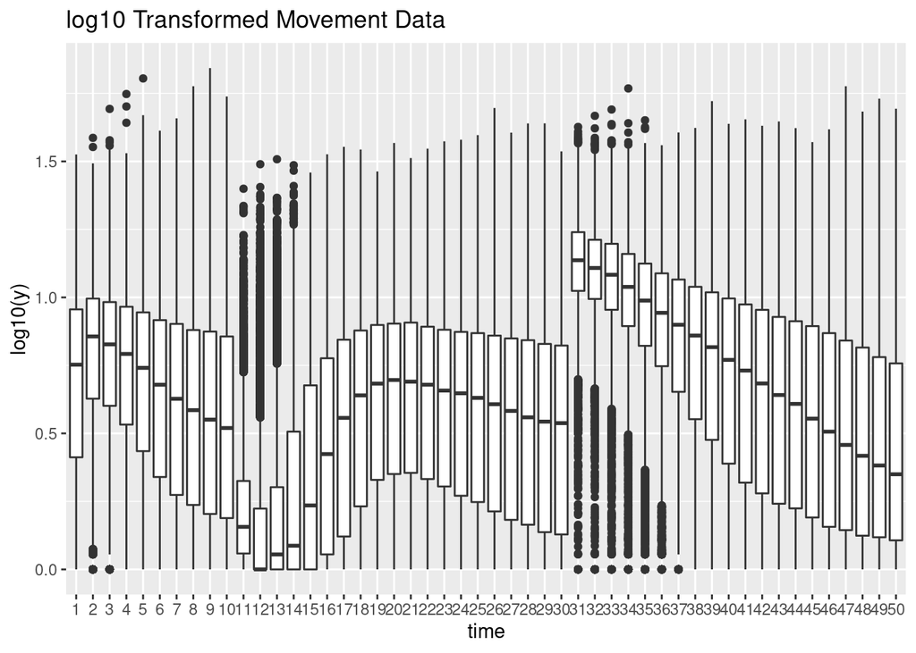

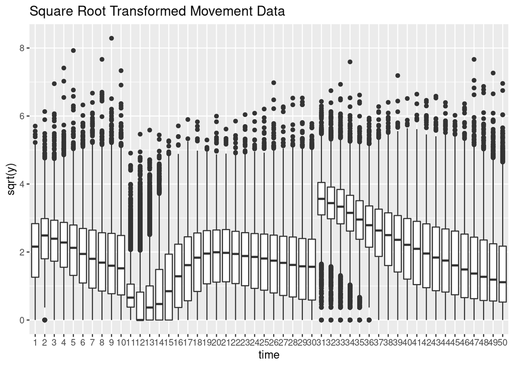

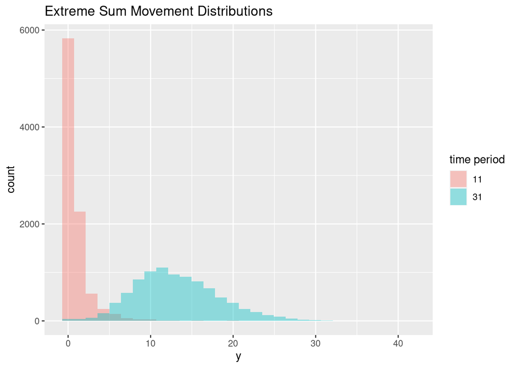

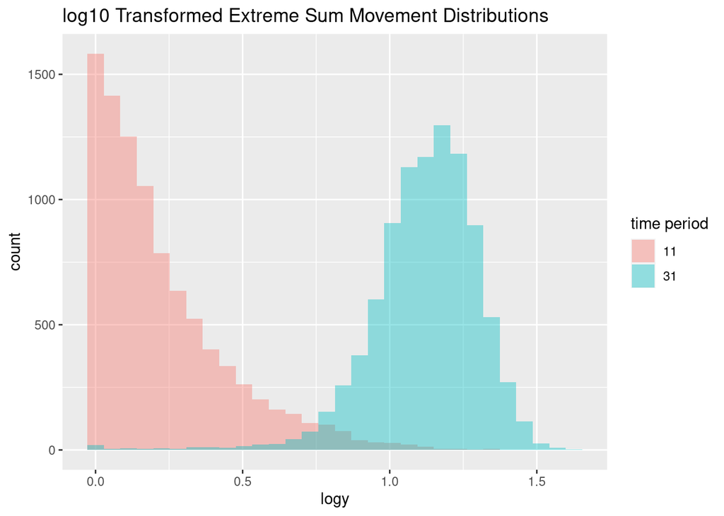

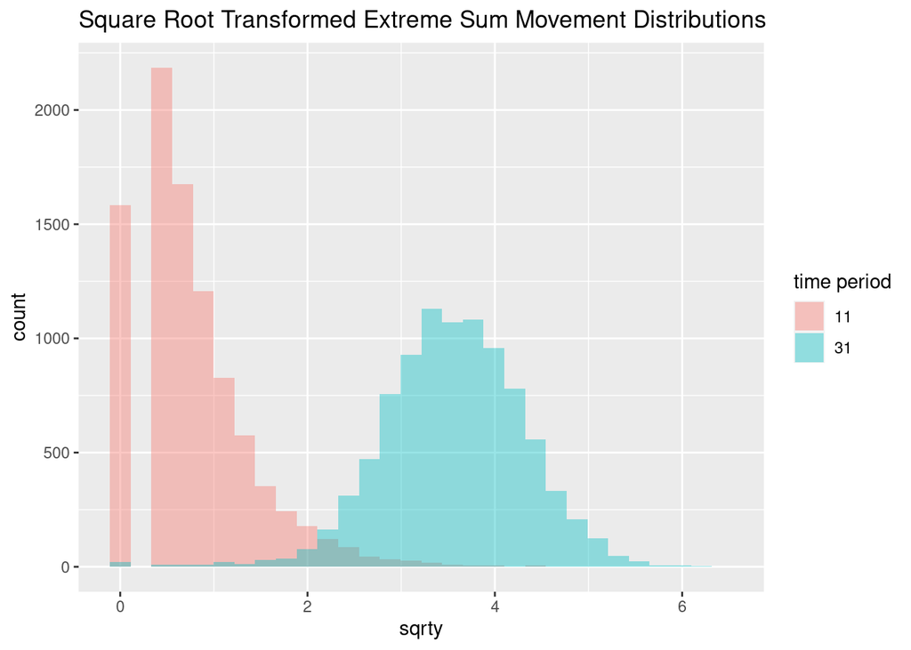

From these graphics I would argue that log10 transformation will offer the greatest increase in symmetry. Both extremes being skewed in opposite directions may mean most distributions will fall somewhere in between and be relatively symmetric.

## Evaluate Change in Heteroscedasticity

Evaluate how distributions of sample variances (for each time period) change when transformation is applied. We would like to see a decrease in the spread of values.

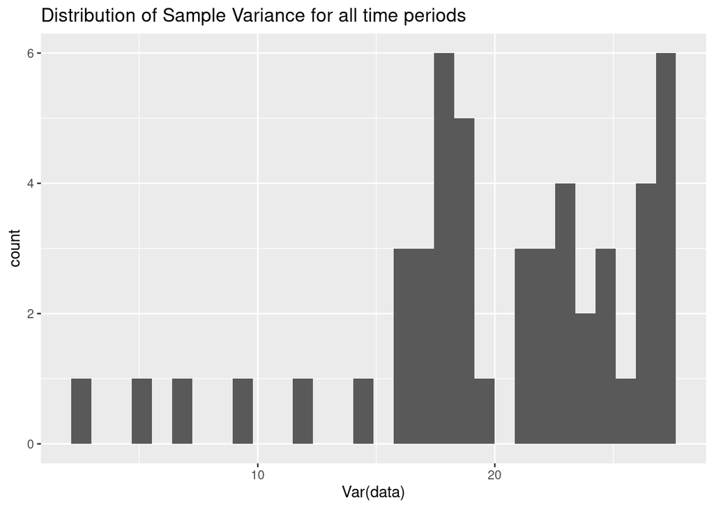

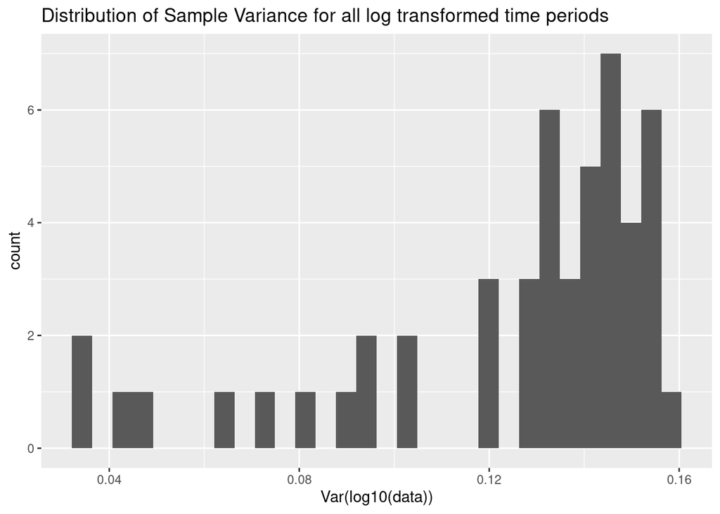

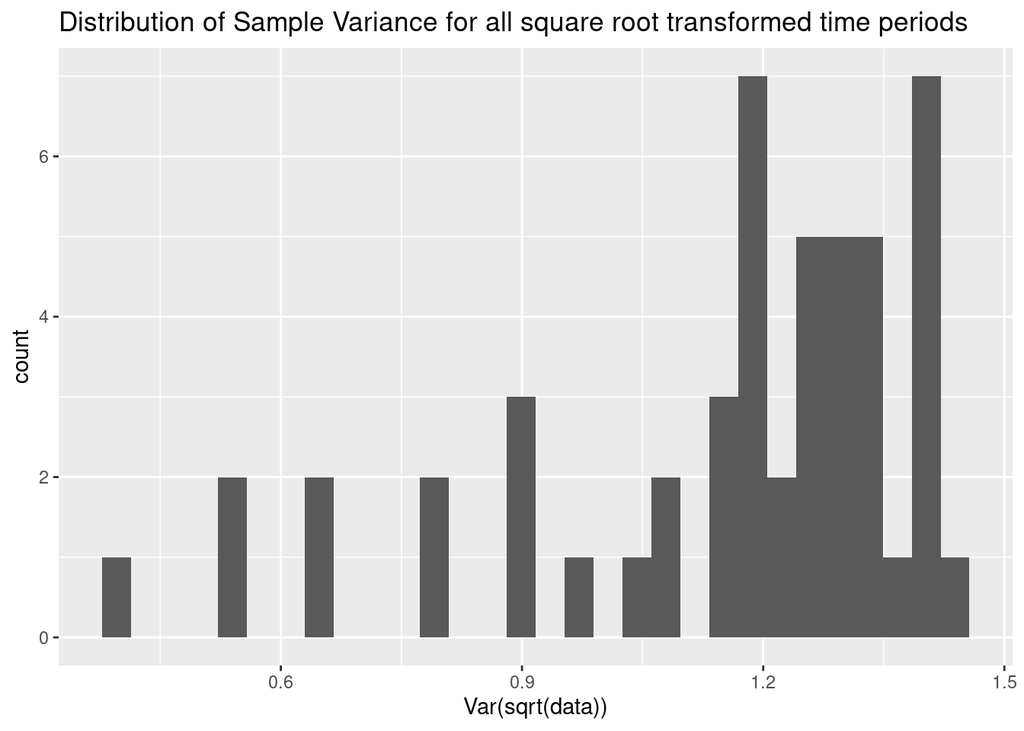

Bi-modality seems probable in untransformed data. This could be a result of light and dark data being evaluated together. May be application of different transformations to Light and Dark phase data would be a good approach?

Log10 data appears to remove bimodality. Also scale is much smaller for logarithmic data. The magnitude of the differences in variance maybe something to take into account. Even though relative spread of sample variances for sqrt and log10 data may be the same, the magnitude of the differences between variances being smaller might improve fit.